# Movies on Netflix, Prime, Hulu and Disney+ Analysis

Dana Eilam, Sivan Itzhaki, Shiraz Israeli

24.6.2021

# Background and goals

In this project, we wanted to analyze information about some of the best movies on our most familiar platforms, like Netflix, Prime video and more. you can find the data set we used [here](https://www.kaggle.com/ruchi798/movies-on-netflix-prime-video-hulu-and-disney).

We wanted to take this everyday subject and thoroughly study it. Our main questions were:

- Is there a linear correlation between IMDb ratings and Rotten Tomatoes ratings?
- Is there a certain distribution to IMDb ratings?

## Importing the data set and Tidying

First we will need to import our data set, which is a simple CSV table. Afterwards we will need to adjust a few things. We can see some NA values in the table, so let’s remove any instance of NA values, while keeping the structural integrity of the table.

```r
# Deleting any NA value in the table

movies <- na.omit(movies, invert=FALSE)
movies <- select(movies, 2:13)
view(movies)
```

# Transformation and Visualization

## Transformation

We noticed that the values of Rotten Tomatoes aren’t represented as numbers, but as strings of percentages. So we needed to transform each value to a number, and for a better comparison and convenience, we transformed it to a scale of 1 - 10, just like IMDb ratings scale.

```r
# Transforming 'Rotten tomatoes' rating to numbers in the right scale

movies$`Rotten Tomatoes` <- as.numeric(sub("%", "", movies$`Rotten Tomatoes`))/10
glimpse(movies)
```

```
## Rows: 3,301
## Columns: 12
## $ ID                <dbl> 1, 2, 3, 4, 5, 6, 7, 8, 9, 10, 11, 12, 13, 14, 15, 1~
## $ Title             <chr> "Inception", "The Matrix", "Avengers: Infinity War",~
## $ Year              <dbl> 2010, 1999, 2018, 1985, 1966, 2018, 2002, 2012, 1981~
## $ Age               <chr> "13+", "18+", "13+", "7+", "18+", "7+", "18+", "18+"~
## $ IMDb              <dbl> 8.8, 8.7, 8.5, 8.5, 8.8, 8.4, 8.5, 8.4, 8.4, 8.3, 8.~
## $ `Rotten Tomatoes` <dbl> 8.7, 8.7, 8.4, 9.6, 9.7, 9.7, 9.5, 8.7, 9.5, 8.9, 9.~
## $ Netflix           <dbl> 1, 1, 1, 1, 1, 1, 1, 1, 1, 1, 1, 1, 1, 1, 1, 1, 1, 1~
## $ Hulu              <dbl> 0, 0, 0, 0, 0, 0, 0, 0, 0, 0, 0, 0, 0, 0, 0, 0, 0, 0~
## $ `Prime Video`     <dbl> 0, 0, 0, 0, 1, 0, 1, 0, 0, 0, 0, 1, 0, 0, 0, 1, 0, 0~
## $ `Disney+`         <dbl> 0, 0, 0, 0, 0, 0, 0, 0, 0, 0, 0, 0, 0, 0, 0, 0, 0, 0~
## $ Type              <dbl> 0, 0, 0, 0, 0, 0, 0, 0, 0, 0, 0, 0, 0, 0, 0, 0, 0, 0~
## $ Directors         <chr> "Christopher Nolan", "Lana Wachowski,Lilly Wachowski", "Anthony Russo,Joe Russo", "Robert Zemeckis", "Sergio Leone", "Bob Persichetti,Peter Ramsey,Rodney Rothman", "Roman Polanski", "Quentin Tarantino", "Steven Spielberg", "Quentin Tarantino", "Martin Scorsese", "Rajkuma…
```

## Visualization

Let’s see of the interesting information we got to work with.

First let’s have a look at the top ten movies by IMDb:

```r
# Finding top ten movies by IMDb rate

movies%>%
  arrange(desc(IMDb))%>%
  slice(1:10)%>%
  select(Title)
```

```
## # A tibble: 10 x 1
##    Title
##    <chr>
##  1 The Dark Knight
##  2 Inception
##  3 The Good, the Bad and the Ugly
##  4 The Matrix
##  5 GoodFellas
##  6 Hearing Is Believing
##  7 Star Wars: The Empire Strikes Back
##  8 Parasite
##  9 The Green Mile
## 10 It's a Wonderful Life
```

Let’s also have a look at the top ten movies by Rotten Tomatoes:

```r
# Finding top ten movies by 'Rotten Tomatoes' rate

movies%>%
  arrange(desc(`Rotten Tomatoes`))%>%
  slice(1:10)%>%
  select(Title)
```

```
## # A tibble: 10 x 1
##    Title
##    <chr>
##  1 3 Idiots
##  2 Bad Genius
##  3 Bill Burr: I'm Sorry You Feel That Way
##  4 Padman
##  5 Kabhi Khushi Kabhie Gham
##  6 Kapoor & Sons
##  7 Everybody's Everything
##  8 Kajaki
##  9 The White Helmets
## 10 John Mulaney: Kid Gorgeous at Radio City
```

Let’s compare both of the ratings methods by graphs:

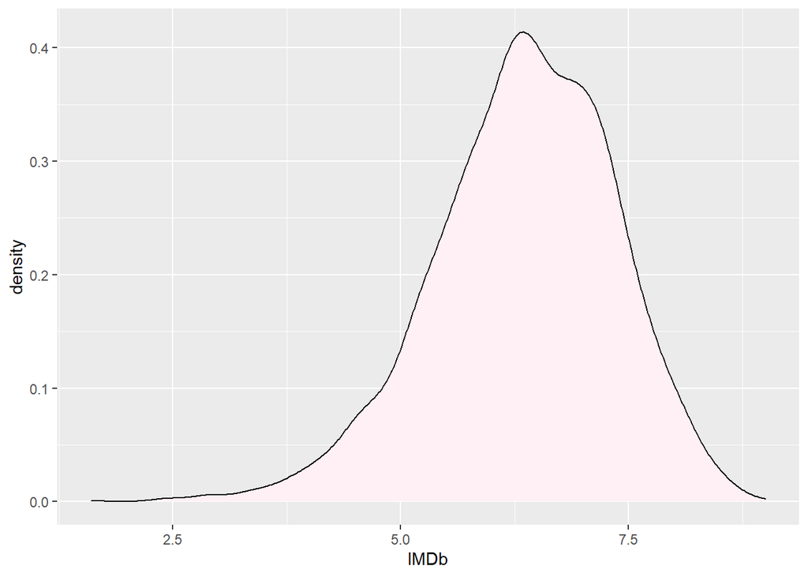

```r
# Making IMDb ratings density graph

movies%>%
  ggplot(aes(IMDb)) + geom_density(fill="lavenderblush")
```

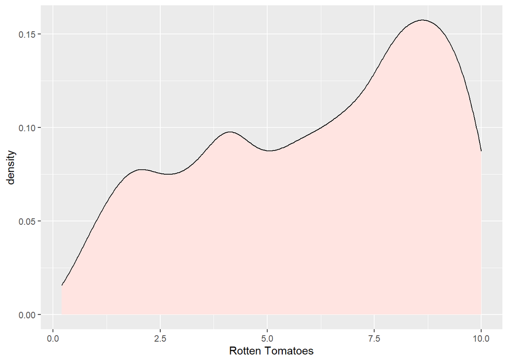

```r
# Making 'Rotten Tomatoes' ratings density graph

movies%>%
  ggplot(aes(`Rotten Tomatoes`)) + geom_density(fill="mistyrose1")
```

We can see that the IMDb rating has interesting and familiar spread! It could hint on a normal distribution, which we’ll check later. Another graph that can show the aforementioned spread:

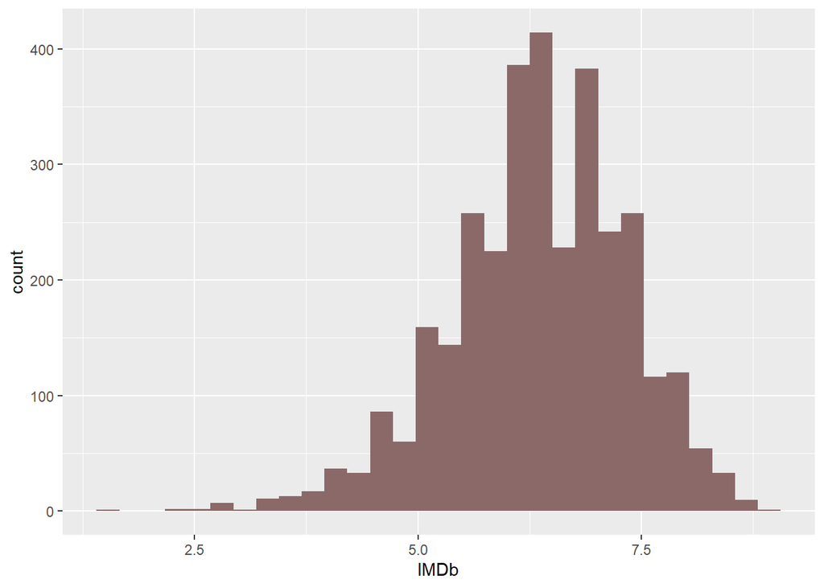

```r
# Making IMDb ratings bars histogram graph

movies%>%
  ggplot(aes(IMDb)) + geom_histogram(fill="rosybrown4")
```

Let’s have a look on some other details. Like how the how age affects the rate by IMDb:

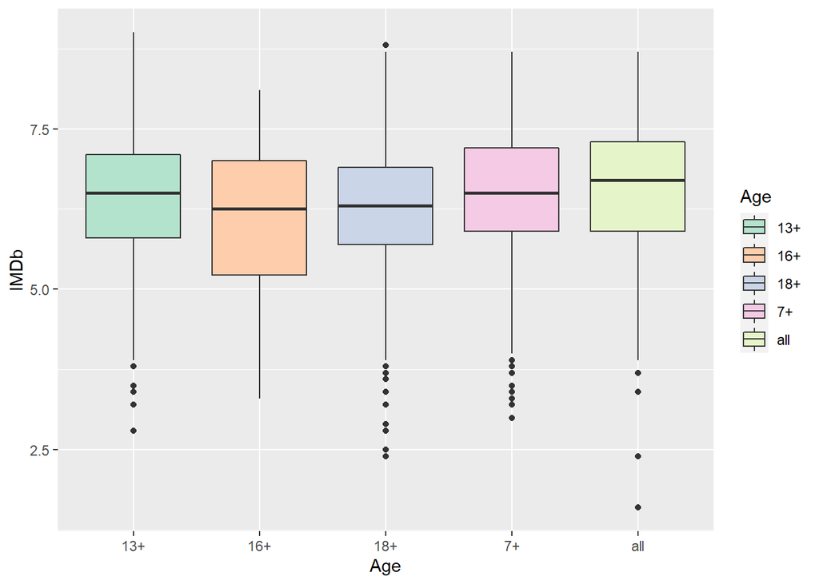

```r
# Making a box-plot graph, age group compared with rate by IMDb

movies %>%
  ggplot(aes(x=Age, y=IMDb, fill=Age))+
  geom_boxplot()+
  scale_fill_brewer(palette = "Pastel2")
```

# Modelling

## Linear regression

We compared both of the rating methods but do they have some kind of linear correlation? Let’s check our thought by using linear regression model.

```r
# Building the linear model and showing the results

model1<-lm(formula = IMDb ~ `Rotten Tomatoes`, data = movies)
summary(model1)
```

```
##
## Call:
## lm(formula = IMDb ~ `Rotten Tomatoes`, data = movies)
##
## Residuals:
##     Min      1Q  Median      3Q     Max
## -4.2383 -0.4346  0.0646  0.4897  2.7838
##
## Coefficients:
##                   Estimate Std. Error t value Pr(>|t|)
## (Intercept)       4.866900   0.031873  152.70   <2e-16 ***
## `Rotten Tomatoes` 0.242662   0.004766   50.92   <2e-16 ***
## ---
## Signif. codes:  0 '***' 0.001 '**' 0.01 '*' 0.05 '.' 0.1 ' ' 1
##
## Residual standard error: 0.7424 on 3299 degrees of freedom
## Multiple R-squared:  0.4401, Adjusted R-squared:  0.4399
## F-statistic:  2593 on 1 and 3299 DF,  p-value: < 2.2e-16
```

[figure not shown]

```r
# Making a point graph, IMDb compared with 'Rotten Tomatoes', and adding the estimate linear line

movies %>%
  ggplot(aes(y=IMDb, x= `Rotten Tomatoes`))+
  geom_point(color="turquoise4")+
  stat_smooth(method = "lm",color="black")
```

We can definitely say that these are good results! Although the R-Squared isn’t so high, we can see our p-value is really low. Beside the variable’s p-value we can see ’***’, which stands for the most significant level of variable possible. Based on the really low p-value, and the graph which seems very homoscedastic, we can determine that there is a correlation between IMDb ratings and Rotten Tomatoes ratings.

## Chi-square goodness of fit test

As we saw on the IMDb density graphs we’ve shown, we can think that it’s maybe a normal distribution. Let’s check our thought by using Chi-square goodness of fit test model.

Our H0: IMDB ~N(Mean,sd^2)

our H1: else

```r
# Dividing IMDb ratings into 4 groups

movies_new <- movies %>%
  mutate(new_IMDb_groups = cut(IMDb, breaks=c(0,5,6.5,7,10)))

# Calculating the expected value of each group according to theoretical normal distribution,
# with estimate mean and sd, multiplied by observations number, in order to get the expected cumulative outcome

expected_c<-pnorm(q=c(5,6.5,7,10), mean = mean(movies$IMDb),sd=sd(movies$IMDb))*3301
expected<- expected_c[1:4] -c(0, expected_c[1:3])

# Showing expected value compared with observed value for each group

movies_new %>%
  count(new_IMDb_groups, name= "observed") %>%
  mutate(expected=expected)%>%
  mutate(chi=((expected-observed)^2)/expected)
```

```
## # A tibble: 4 x 4
##   new_IMDb_groups observed expected    chi
## * <fct>              <int>    <dbl>  <dbl>
## 1 (0,5]                316     286. 3.11
## 2 (5,6.5]             1540    1562. 0.310
## 3 (6.5,7]              611     607. 0.0309
## 4 (7,10]               834     846. 0.164
```

```r
# Calculating the empirical chi square - the statistic and showing the results

movies_new %>%
  count(new_IMDb_groups, name= "observed") %>%
  mutate(expected=expected)%>%
  mutate(chi=((expected-observed)^2)/expected)%>%
  mutate(statistic=sum(((expected-observed)^2)/expected))%>%
  slice(1:1)%>%
  select(statistic)
```

```
## # A tibble: 1 x 1
##   statistic
##       <dbl>
## 1      3.61
```

We can see we have a good result! Our statistic is very small, and according to our theoretical chi square with level of significance of 0.05 (a=0.05), and df=1 (4-2-1=1), we have got a value of 3.841, which is higher than our statistic (3.61). Therefore, we will not reject our H0, which means that IMDb rating’s distribution is normal, as we thought.

# Conclusion

In our project we experienced and applied the material learned in this course, while researching the everyday subject of movies. We used various visualizations methods we learned in class and we’ve shown various familiar graphs. We raised some questions and hypotheses along the project, which eventually been answered with different modeling methods. We hope you gained some information from this project and enjoyed reading it :)